# ReceivingNews first wave - power simulation

```
By Valentin Guigon
June 2023
```

# Power simulation at the first wave

We hypothesized that participants’ veracity estimation was significantly explained by news’ content uncertainty, as assessed by news’ content precision level (i.e., *Imprecision*). After a first acquisition of data, with n=79, we simulate the current power for the fixed simple effect of the variable *Imprecision*, and for the fixed interaction effect of the variable *Imprecision* with the variable *Veracity*. Then we simulate the power for lower fixed effects and more participants. We set up the number of simulations at 100.

# I. Full control model

We formulated a model with control variables but removed complexity from the random structure to save computation time. The model is written with the form:

```
Success ~ Veracity*Imprecision + Veracity*Polarization + Confidence + Veracity*Theme +
Age + Sex + Education + Ec + (1|Subject)
```

## A. Current power

We simulate the current power for our model. Effect sizes are: - Imprecision: -0.1974335 (odds-ratio = 0.8208347) - Polarization: -0.1726263 (odds-ratio = 0.841452) - Interaction of imprecision with veracity judgment: 0.3887842 (odds-ratio = 1.4751861) - Interaction of polarization with veracity judgment: 0.5704769 (odds-ratio = 1.7691105)

The current power for the interaction of imprecision with veracity judgment is:

```
## Power for predictor 'VeracityFalse:Imprecision', (95% confidence interval):
##       100.0% (96.38, 100.0)
##
## Test: z-test
##       Effect size for VeracityFalse:Imprecision is 0.39
##
## Based on 100 simulations, (0 warnings, 0 errors)
## alpha = 0.05, nrow = 3792
##
## Time elapsed: 0 h 25 m 9 s
##
## nb: result might be an observed power calculation
```

The current power for the interaction of polarization with veracity judgment is:

```
## Power [user defined], (95% confidence interval):
##        0.00% ( 0.00,  3.62)
##
## Test: [user defined function]
##
## Based on 100 simulations, (0 warnings, 100 errors)
## alpha = 0.05, nrow = 3792
##
## Time elapsed: 0 h 20 m 51 s
##
## nb: result might be an observed power calculation
```

## B. Simulation of power

We simulate the power for Imprecision and Polarization simple effects with 80, 150, 200 and 250 subjects. The simulated power is:

```
## Power for predictor 'Imprecision', (95% confidence interval),
## by largest value of Subject:
##      80: 99.00% (94.55, 99.97) - 3840 rows
##     150: 100.0% (96.38, 100.0) - 7200 rows
##     200: 100.0% (96.38, 100.0) - 9600 rows
##     250: 100.0% (96.38, 100.0) - 12000 rows
##
## Time elapsed: 1 h 45 m 5 s
```

```
## Power for predictor 'Polarization', (95% confidence interval),
## by largest value of Subject:
##      80: 87.00% (78.80, 92.89) - 3840 rows
##     150: 99.00% (94.55, 99.97) - 7200 rows
##     200: 100.0% (96.38, 100.0) - 9600 rows
##     250: 100.0% (96.38, 100.0) - 12000 rows
##
## Time elapsed: 1 h 49 m 17 s
```

**However the computation time is too high (>3h)**

# II. Simpler model

To save computation time, we remove the sociodemographics variables. The model is now written with the form:

```
Success ~ Veracity * Imprecision + Veracity * Polarization + Confidence + Veracity * Theme + (1 | Subject)
```

We simulate the current power for our model. Effect sizes are: - Imprecision: -0.1977151 (odds-ratio = 0.8206036) - Polarization: -0.1733143 (odds-ratio = 0.8408733) - Interaction of imprecision with veracity judgment: -0.6760743 (odds-ratio = 0.5086097) - Interaction of polarization with veracity judgment: 0.38926 (odds-ratio = 1.4758882)

## A. Actual effect size

We simulate the power for 80, 150, 200 and 250 subjects. The simulated power is:

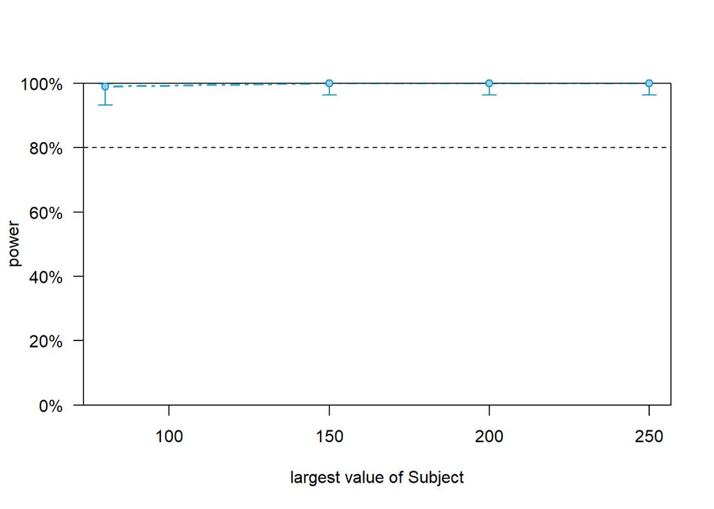

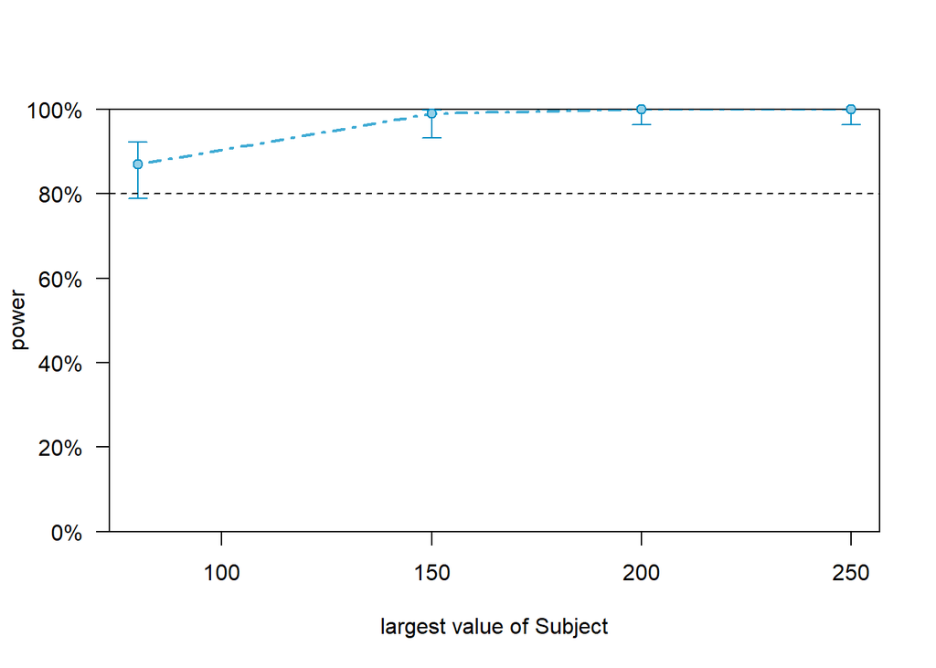

## B. Low effect size

We lower *Imprecision* fixed main effect at -0.05 (initially at -0.2): The simulated power is:

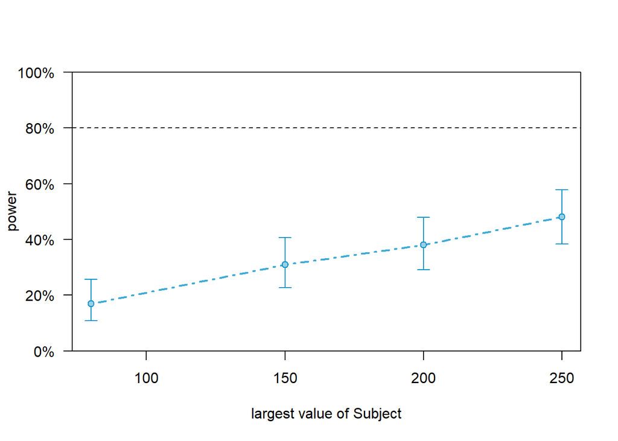

We lower *Polarization* fixed main effect at -0.05 (initially at -0.17): The simulated power is:

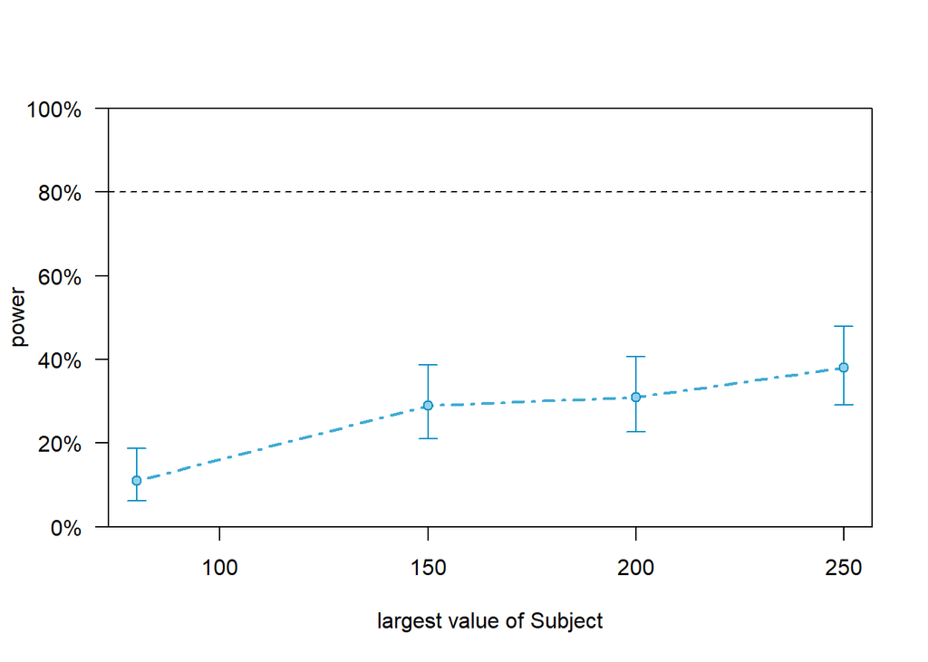

The effect size is too low to have good power.

## C. Mid effet size

### Simple effect with 250 subjects

We lower *Imprecision* fixed main effect at -0.1 (initially at -0.2):

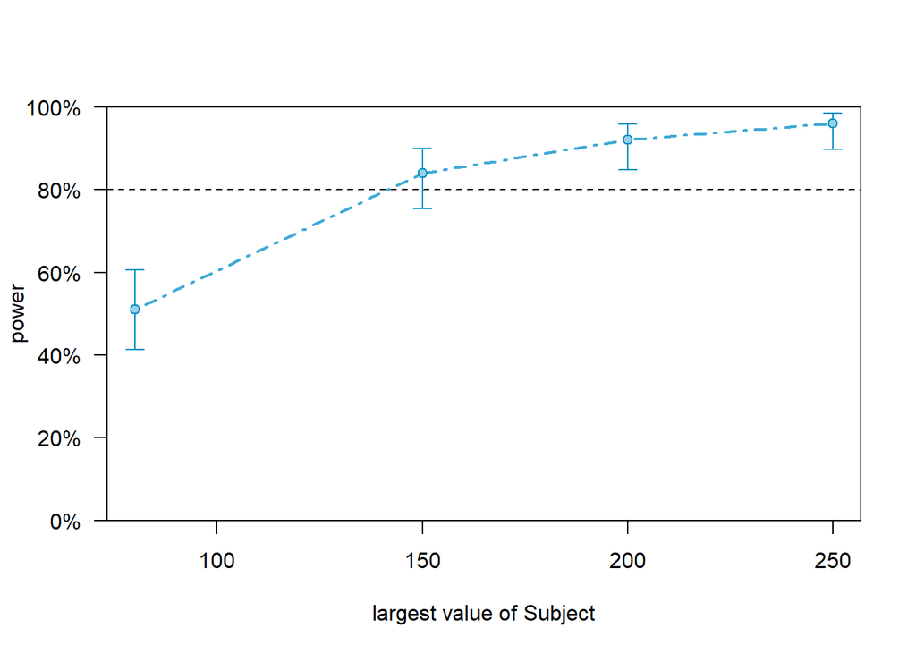

We detect an effect size as low as -.1 with power >92% from 200 subjects.

We lower *Polarization* fixed main effect at -0.1 (initially at -0.2):

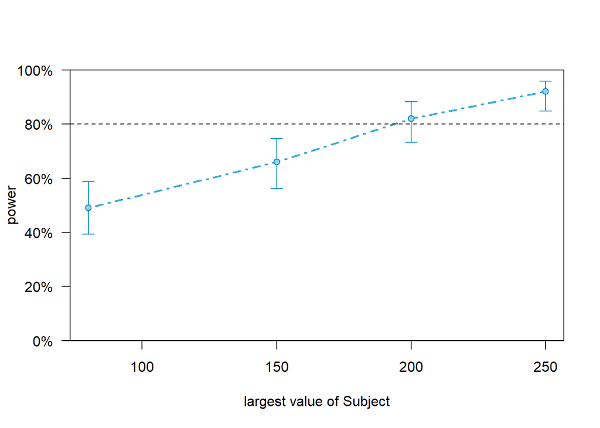

We detect an effect size as low as -.1 with power >92% from 250 subjects.

### Interaction effects with 250 subjects

We simulate the power for Imprecision interacting with Veracity with 80, 150, 200 and 250 subjects and lower the fixed effect at -0.25. The simulated power is:

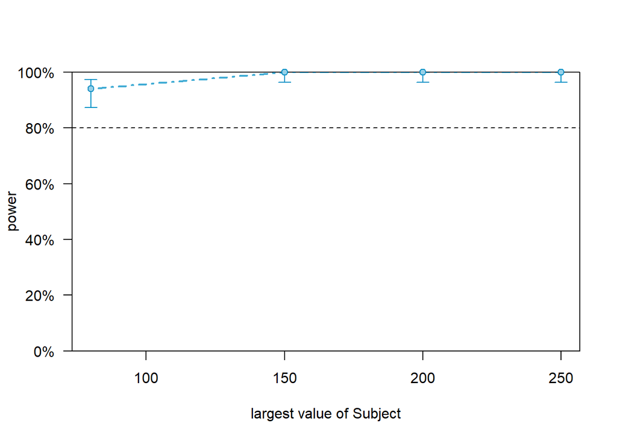

We simulate the power for Polarization interacting with Veracity with 80, 150, 200 and 250 subjects and lower the fixed effect at -0.25. The simulated power is:

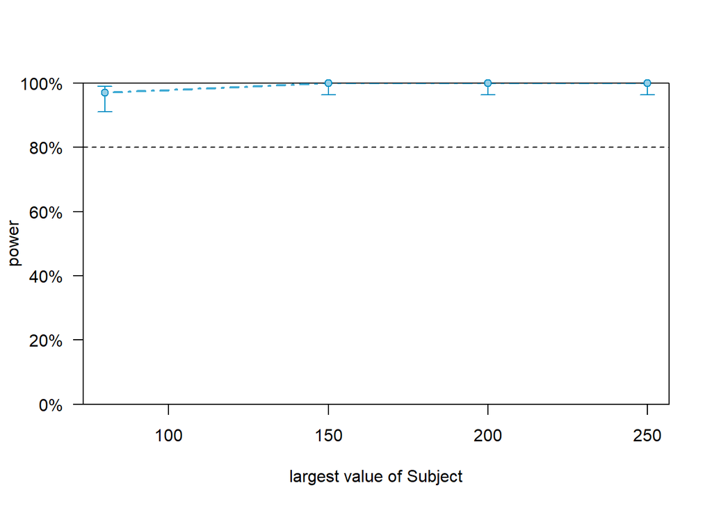

## D. Interaction fixed effects against main fixed effects

We compare the power for the fixed Imprecision interaction effect with that of the fixed main effect.

First, we check the simulated current power for the interaction fixed effects:

```
## Power for model comparison, (95% confidence interval):
##       100.0% (96.38, 100.0)
##
## Test: Likelihood ratio
##       Comparison to Success ~ Veracity + Imprecision + Polarization + Confidence + Veracity * Theme + (1 | Subject) + [re]
##
## Based on 100 simulations, (0 warnings, 0 errors)
## alpha = 0.05, nrow = 3792
##
## Time elapsed: 0 h 27 m 19 s
##
## nb: result might be an observed power calculation
```

We simulate the power for 80, 150, 200 and 250 subjects, lower the fixed effect at -0.25 and compare the model to only specified fixed effects in the alternative model. The simulated power for the interaction is:

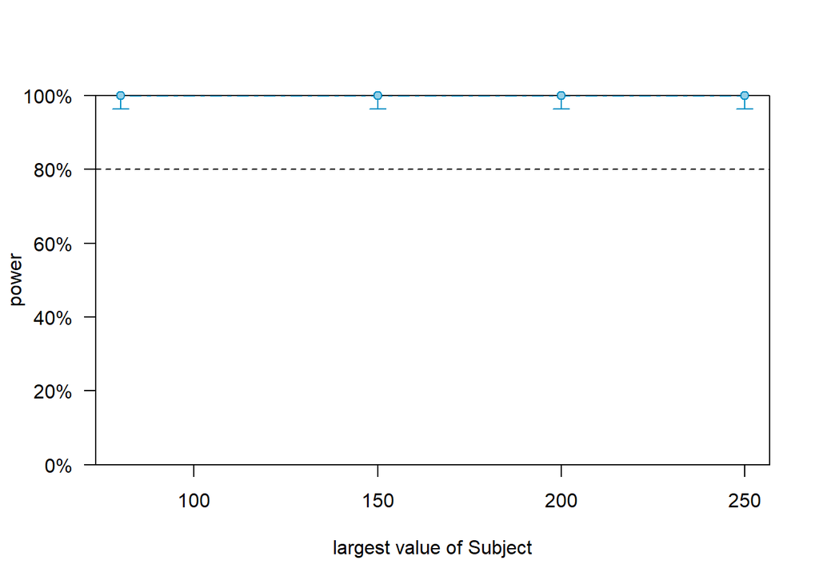

# To exceed the 95% Power for Imprecision main effect, with a fixed effect lower than that of the first wave, we need to exceed 200 participants. We will aim for 250 participants.